# Visualisation Assocation Cholesterol

Geoffrey BOILAY

20 juin, 2023

# Objectif

L’Objectif est de trouver une éventuelle assiociation entre le cholesterol et l’abeta42.  
Pour y parvenir, nous allons analyser la relation entre ces deux facteurs et segmenter l’association linéaire.

# Association entre Abeta42 et Cholesterol_total

## Modèle avec le Cholesterol²

```
##
## Call:
## lm(formula = reformulate(termlabels = x, response = y), data = data)
##
## Residuals:
##      Min       1Q   Median       3Q      Max
## -2.82265 -0.65588 -0.04786  0.58550  2.76518
##
## Coefficients:
##                       Estimate Std. Error t value Pr(>|t|)
## (Intercept)          -0.355985   0.039790  -8.946   <2e-16 ***
## cholesterol_total     0.059078   0.031887   1.853   0.0642 .
## cholesterol_total_sq -0.009681   0.009342  -1.036   0.3003
## ma1                   0.804420   0.057861  13.903   <2e-16 ***
## ---
## Signif. codes:  0 '***' 0.001 '**' 0.01 '*' 0.05 '.' 0.1 ' ' 1
##
## Residual standard error: 0.9077 on 1004 degrees of freedom
## Multiple R-squared:  0.1685, Adjusted R-squared:  0.166
## F-statistic:  67.8 on 3 and 1004 DF,  p-value: < 2.2e-16
```

La P-valeur du cholesterol carré est de 0.3. Elle est donc non significative.

## Smooth spline

### Calcul du nombre de spline

```
## Call:
## smooth.spline(x = data_chol$cholesterol_total, y = data_chol$abeta42,
##     cv = TRUE)
##
## Smoothing Parameter  spar= 1.172267  lambda= 0.1274095 (14 iterations)
## Equivalent Degrees of Freedom (Df): 3.065585
## Penalized Criterion (RSS): 195.8222
## PRESS(l.o.o. CV): 0.9835423
```

Le modèle trouve 3 splines

### Représentation graphique

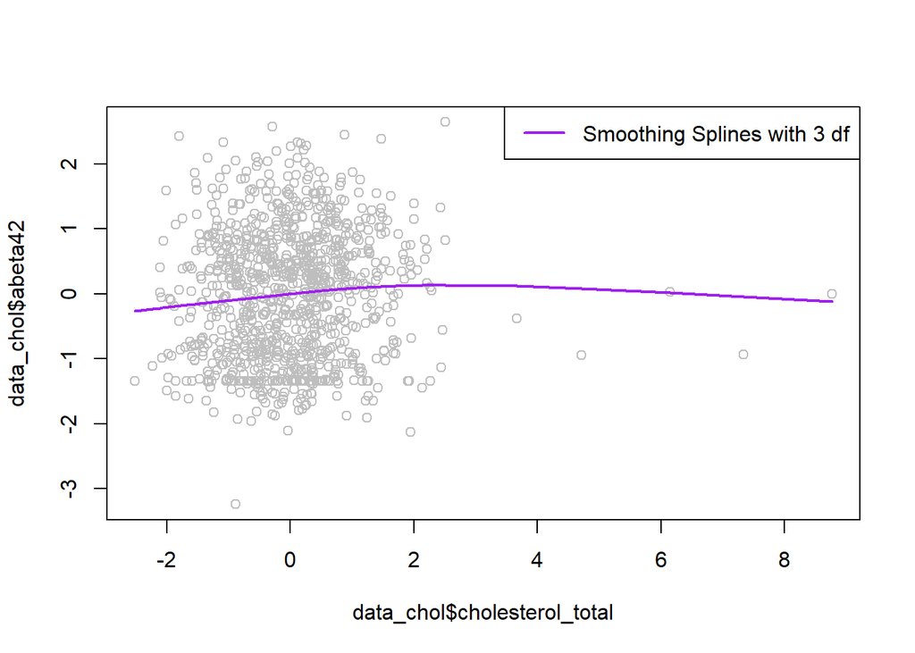

On peut remarquer que le modèle est sensible aux valeurs extrèmes.

### Calcul du nombre de spline sans valeurs extrèmes

On supprime les valeurs de cholesterol_total > 3.5

```
## Call:
## smooth.spline(x = data_chol_outlier$cholesterol_total, y = data_chol_outlier$abeta42,
##     cv = TRUE)
##
## Smoothing Parameter  spar= 1.499953  lambda= 307.0626 (27 iterations)
## Equivalent Degrees of Freedom (Df): 2.003235
## Penalized Criterion (RSS): 193.7156
## PRESS(l.o.o. CV): 0.9850904
```

Le modèle trouve 2 splines

### Représentation graphique sans valeurs extrèmes

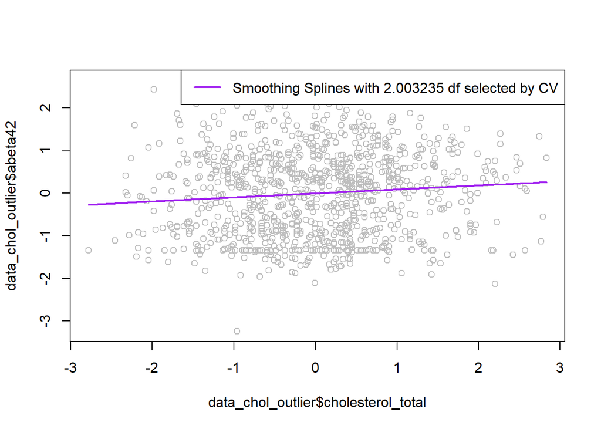

## Représentation graphique d’une regression linéaire avec une cassure en x = 0

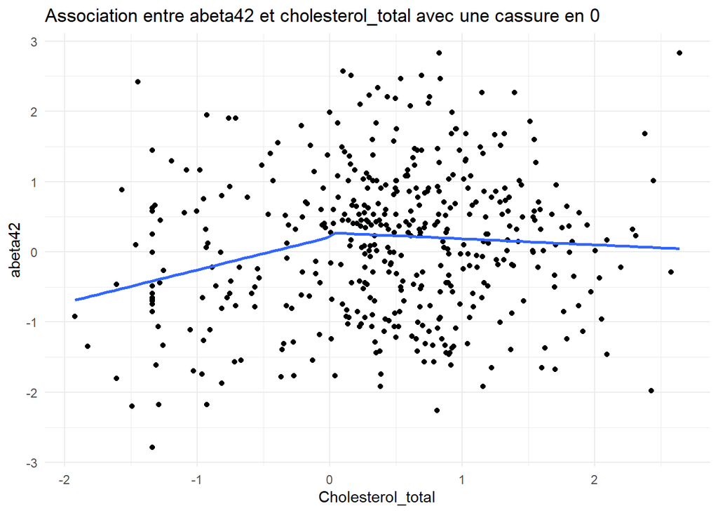

On remarque que la tendance de la régression linéaire s’inverse après la cassure.

## Analyse sur la variable MA

La variable MA correspond aux patients diagnostiqués atteint de la Maladie d’Alzheimer en dichotomique.

### Regression linéaire

Les regressions linéraires contiennent comme variables explicatives le cholesterol total et le cholesterol total au carré.  
La variable à expliquer est abeta42.  
Le cholesterol est standardisé et ne contient pas de valeurs extrèmes (> 3.5)

#### MA = 0

```
##
## Call:
## lm(formula = abeta42 ~ cholesterol_total + cholesterol_total_sqrt,
##     data = data_ma_outlier_0)
##
## Residuals:
##     Min      1Q  Median      3Q     Max
## -2.8640 -0.7838 -0.1705  0.6488  2.7081
##
## Coefficients:
##                         Estimate Std. Error t value Pr(>|t|)
## (Intercept)            -0.372756   0.049197  -7.577 1.49e-13 ***
## cholesterol_total       0.006341   0.041678   0.152    0.879
## cholesterol_total_sqrt  0.004298   0.031233   0.138    0.891
## ---
## Signif. codes:  0 '***' 0.001 '**' 0.01 '*' 0.05 '.' 0.1 ' ' 1
##
## Residual standard error: 0.941 on 557 degrees of freedom
## Multiple R-squared:  7.56e-05,   Adjusted R-squared:  -0.003515
## F-statistic: 0.02106 on 2 and 557 DF,  p-value: 0.9792
```

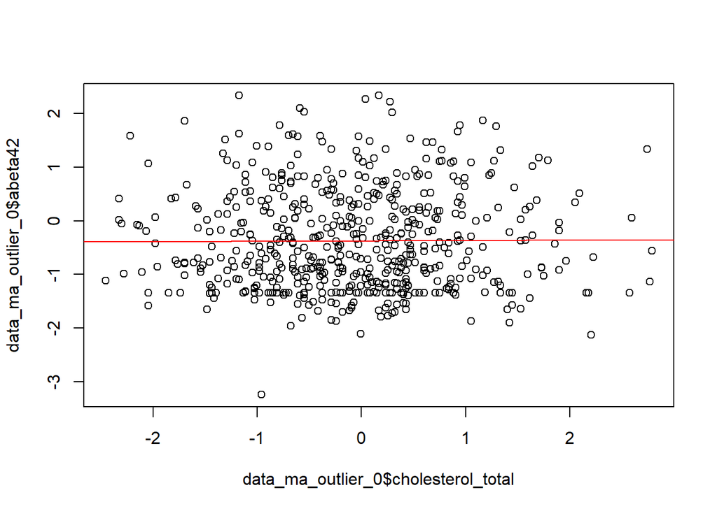

On remarque que la pente de la régression semble nulle.

#### MA = 1

```
##
## Call:
## lm(formula = abeta42 ~ cholesterol_total + cholesterol_total_sqrt,
##     data = data_ma_outlier_1)
##
## Residuals:
##      Min       1Q   Median       3Q      Max
## -2.26143 -0.44125  0.04796  0.55811  2.38217
##
## Coefficients:
##                        Estimate Std. Error t value Pr(>|t|)
## (Intercept)             0.49050    0.05195   9.442  < 2e-16 ***
## cholesterol_total       0.11614    0.04037   2.877  0.00421 **
## cholesterol_total_sqrt -0.05435    0.02957  -1.838  0.06678 .
## ---
## Signif. codes:  0 '***' 0.001 '**' 0.01 '*' 0.05 '.' 0.1 ' ' 1
##
## Residual standard error: 0.864 on 440 degrees of freedom
## Multiple R-squared:  0.02181,    Adjusted R-squared:  0.01736
## F-statistic: 4.905 on 2 and 440 DF,  p-value: 0.007821
```

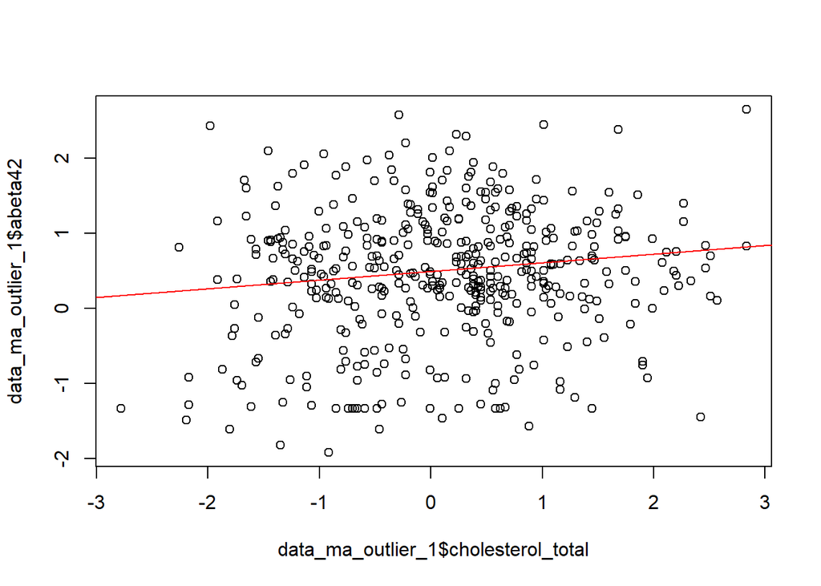

On remarque que la pente de la régression a une tendance positive.

## Modèles linéaires avec séparation du cholesterol_total en 0 en fonction de MA

Nous avons remarqué plus haut que la tendance du cholesterol_total sur abeta42 s’inversent en 0.  
Nous allons voir si cette tendance s’accentue en fonction du diagnostic de la Maladie d’Alzheimer (variable MA)

### Modèle linéaire sur cholesterol_total, MA et l’intéraction

```
##
## Call:
## lm(formula = abeta42 ~ cholesterol_total + ma + cholesterol_total *
##     ma, data = data_chol_outlier)
##
## Residuals:
##      Min       1Q   Median       3Q      Max
## -2.86397 -0.67030 -0.03606  0.61737  2.71007
##
## Coefficients:
##                       Estimate Std. Error t value Pr(>|t|)
## (Intercept)          -0.368805   0.038567  -9.563   <2e-16 ***
## cholesterol_total     0.006345   0.040231   0.158    0.875
## ma                    0.801432   0.058083  13.798   <2e-16 ***
## cholesterol_total:ma  0.093552   0.057732   1.620    0.105
## ---
## Signif. codes:  0 '***' 0.001 '**' 0.01 '*' 0.05 '.' 0.1 ' ' 1
##
## Residual standard error: 0.9083 on 999 degrees of freedom
## Multiple R-squared:  0.1698, Adjusted R-squared:  0.1673
## F-statistic: 68.12 on 3 and 999 DF,  p-value: < 2.2e-16
```

### Modèle linéaire sur le cholesterol_total séparé, MA et les intéractions

```
##
## Call:
## lm(formula = abeta42 ~ chol1 + chol2 + ma + chol1 * ma + chol2 *
##     ma, data = data_chol_outlier)
##
## Residuals:
##      Min       1Q   Median       3Q      Max
## -2.86796 -0.66689 -0.04789  0.62357  2.71570
##
## Coefficients:
##             Estimate Std. Error t value Pr(>|t|)
## (Intercept) -0.38706    0.06394  -6.053    2e-09 ***
## chol1       -0.01681    0.07620  -0.221   0.8254
## chol2        0.03095    0.07967   0.388   0.6977
## ma           0.94516    0.09803   9.641   <2e-16 ***
## chol1:ma     0.28022    0.11704   2.394   0.0168 *
## chol2:ma    -0.06563    0.11066  -0.593   0.5533
## ---
## Signif. codes:  0 '***' 0.001 '**' 0.01 '*' 0.05 '.' 0.1 ' ' 1
##
## Residual standard error: 0.9072 on 997 degrees of freedom
## Multiple R-squared:  0.1735, Adjusted R-squared:  0.1694
## F-statistic: 41.86 on 5 and 997 DF,  p-value: < 2.2e-16
```

### Modèle linéaire sur le cholesterol_total séparé sur MA = 0

```
##
## Call:
## lm(formula = abeta42 ~ chol1 + chol2, data = data_ma_0)
##
## Residuals:
##     Min      1Q  Median      3Q     Max
## -2.8693 -0.7756 -0.1659  0.6378  2.7085
##
## Coefficients:
##              Estimate Std. Error t value Pr(>|t|)
## (Intercept) -0.375677   0.058343  -6.439 2.58e-10 ***
## chol1       -0.006907   0.081175  -0.085    0.932
## chol2        0.008459   0.056609   0.149    0.881
## ---
## Signif. codes:  0 '***' 0.001 '**' 0.01 '*' 0.05 '.' 0.1 ' ' 1
##
## Residual standard error: 0.9377 on 562 degrees of freedom
## Multiple R-squared:  4.191e-05,  Adjusted R-squared:  -0.003517
## F-statistic: 0.01178 on 2 and 562 DF,  p-value: 0.9883
```

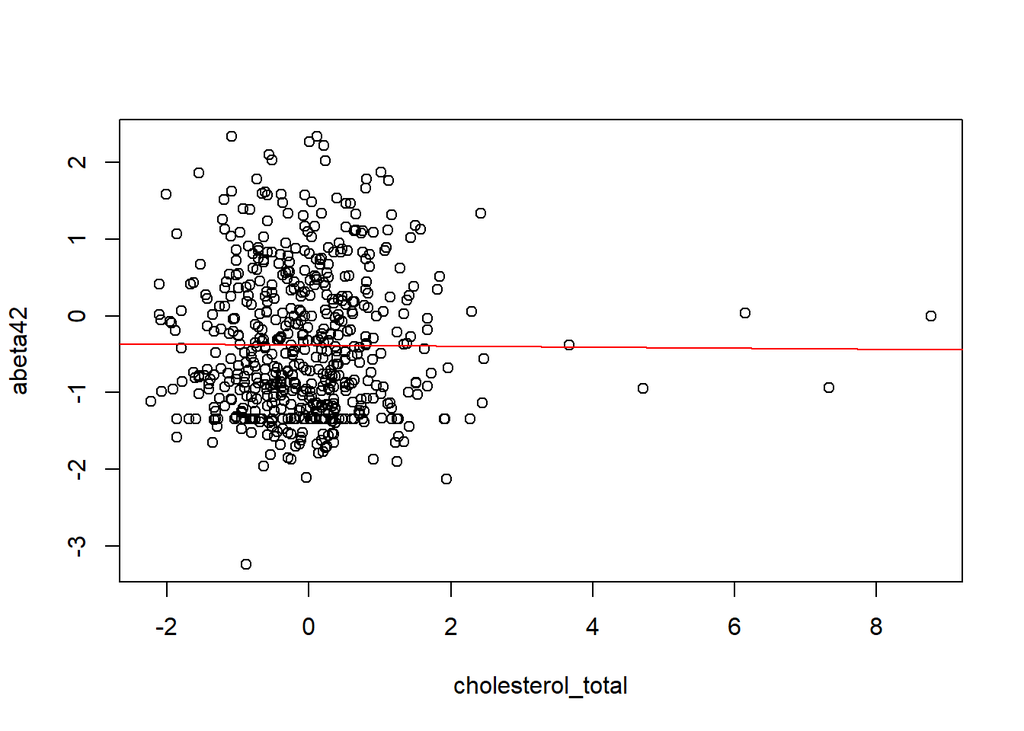

### Modèle linéaire sur le cholesterol_total séparé sur MA = 1

```
##
## Call:
## lm(formula = abeta42 ~ chol1 + chol2, data = data_ma_1)
##
## Residuals:
##      Min       1Q   Median       3Q      Max
## -2.23838 -0.42987  0.05215  0.56828  2.38882
##
## Coefficients:
##             Estimate Std. Error t value Pr(>|t|)
## (Intercept)  0.56077    0.07047   7.958  1.5e-14 ***
## chol1        0.28853    0.09228   3.127  0.00189 **
## chol2       -0.04186    0.08303  -0.504  0.61439
## ---
## Signif. codes:  0 '***' 0.001 '**' 0.01 '*' 0.05 '.' 0.1 ' ' 1
##
## Residual standard error: 0.8627 on 440 degrees of freedom
## Multiple R-squared:  0.02483,    Adjusted R-squared:  0.0204
## F-statistic: 5.602 on 2 and 440 DF,  p-value: 0.003959
```

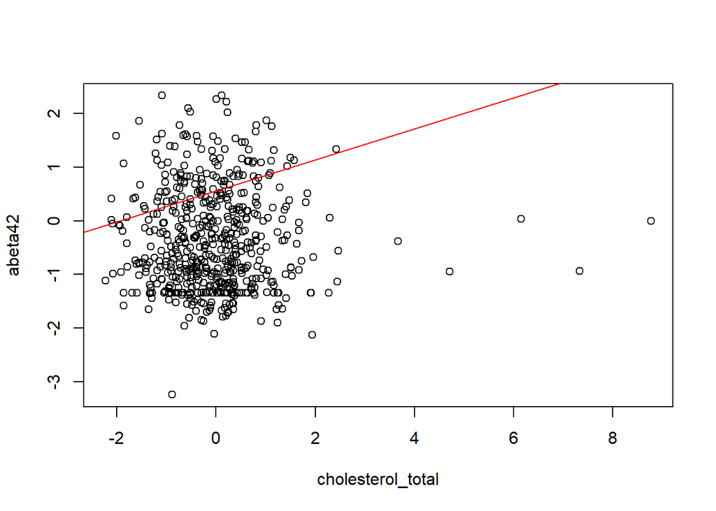

[output not shown]

# Association entre Abeta42 et Cholesterol_ldl

## Smooth spline

Nous regardons quel type de cholesterol semble avoir le plus d’effet sur l’abeta42.

### Cholesterol_hdl

```
## Call:
## smooth.spline(x = data_chol_hdl$cholesterol_hdl, y = data_chol_hdl$abeta42,
##     cv = TRUE)
##
## Smoothing Parameter  spar= 1.499965  lambda= 1039.815 (29 iterations)
## Equivalent Degrees of Freedom (Df): 2.000361
## Penalized Criterion (RSS): 77.87203
## PRESS(l.o.o. CV): 0.9903887
```

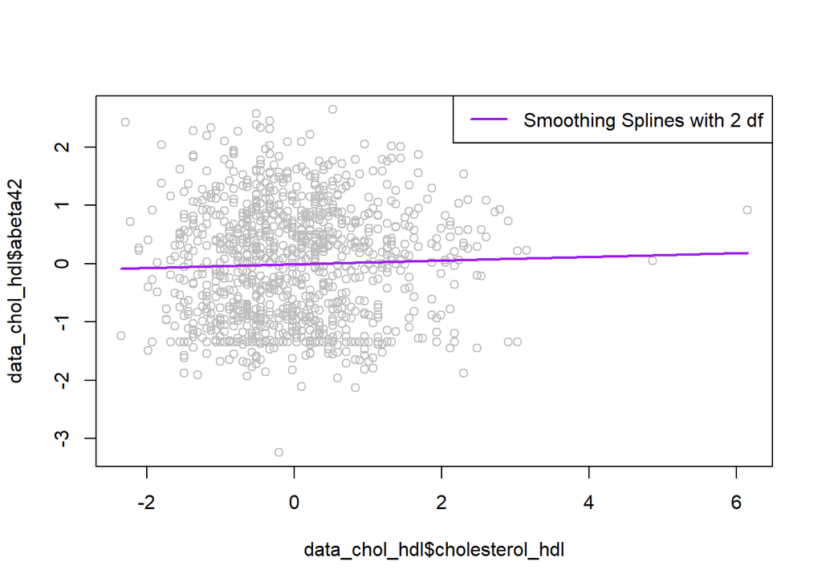

### Cholesterol_ldl

```
## Call:
## smooth.spline(x = data_chol_ldl$cholesterol_ldl, y = data_chol_ldl$abeta42,
##     cv = TRUE)
##
## Smoothing Parameter  spar= 1.499954  lambda= 337.2194 (27 iterations)
## Equivalent Degrees of Freedom (Df): 2.002036
## Penalized Criterion (RSS): 165.1216
## PRESS(l.o.o. CV): 0.9787433
```

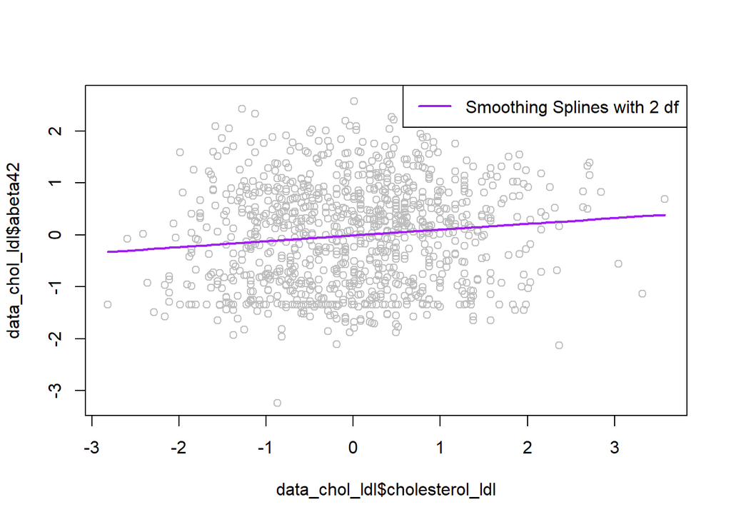

On remarque une pente plus élevée que sur la représentation graphique avec le cholesterol_hdl

## Segmentation

L’objectif est de trouver le point le plus juste pour la cassure dans la droite de regression linéaire.

### Nuage de point abeta42 ~ Cholesterol_ldl

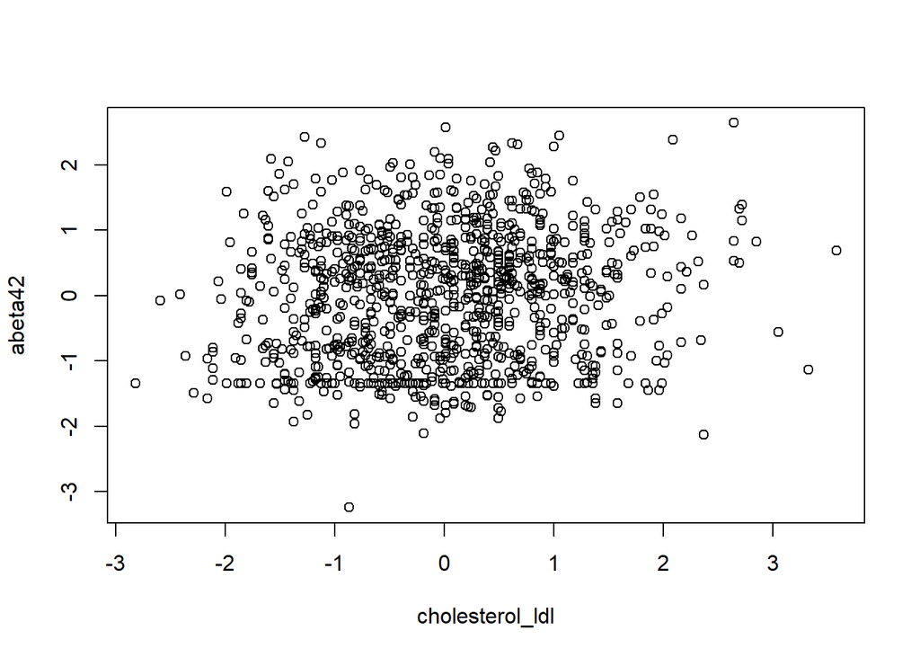

### Model 1 (modèle simple)

#### Modèle linéaire

```
##
## Call:
## lm(formula = abeta42 ~ cholesterol_ldl, data = data_ldl)
##
## Residuals:
##      Min       1Q   Median       3Q      Max
## -3.13391 -0.86324  0.06538  0.74874  2.58409
##
## Coefficients:
##                  Estimate Std. Error t value Pr(>|t|)
## (Intercept)     -0.007688   0.031236  -0.246 0.805643
## cholesterol_ldl  0.111370   0.031252   3.564 0.000383 ***
## ---
## Signif. codes:  0 '***' 0.001 '**' 0.01 '*' 0.05 '.' 0.1 ' ' 1
##
## Residual standard error: 0.9898 on 1002 degrees of freedom
## Multiple R-squared:  0.01252,    Adjusted R-squared:  0.01153
## F-statistic:  12.7 on 1 and 1002 DF,  p-value: 0.000383
```

#### AIC

```
## [1] 2832.547
```

#### segment

```
##
##  ***Regression Model with Segmented Relationship(s)***
##
## Call:
## segmented.lm(obj = mod, seg.Z = ~cholesterol_ldl, psi = 0)
##
## Estimated Break-Point(s):
##                         Est. St.Err
## psi1.cholesterol_ldl -1.557   0.37
##
## Meaningful coefficients of the linear terms:
##                    Estimate Std. Error t value Pr(>|t|)
## (Intercept)          0.8896     0.9184   0.969    0.333
## cholesterol_ldl      0.6622     0.4884   1.356    0.175
## U1.cholesterol_ldl  -0.5705     0.4896  -1.165       NA
##
## Residual standard error: 0.9895 on 1000 degrees of freedom
## Multiple R-Squared: 0.01501,  Adjusted R-squared: 0.01206
##
## Boot restarting based on 6 samples. Last fit:
## Convergence attained in 2 iterations (rel. change 1.3914e-07)
```

Le point de cassure estimé est à -1.557

#### AIC Segment

```
## [1] 2834.007
```

#### Plot

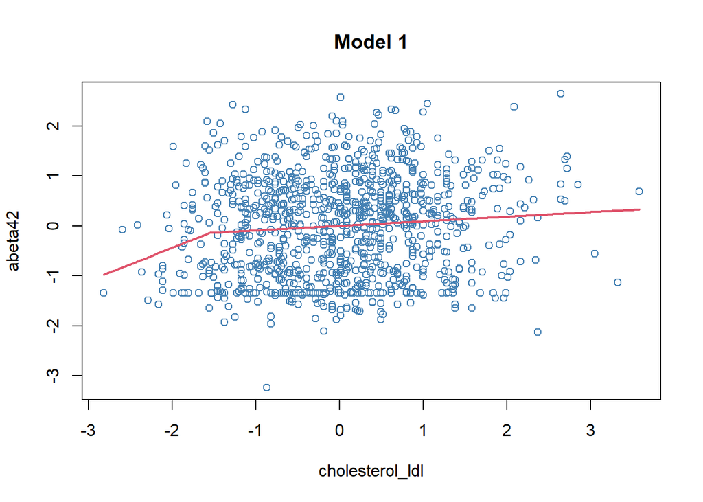

### Model 2 (modèle complet)

#### Modèle linéaire

```
##
## Call:
## lm(formula = abeta42 ~ cholesterol_ldl + age + sexe + niveau_etude_reg +
##     mmse + ch + dia + hta_med + imc_reg + apoe.reg2, data = data_ldl)
##
## Residuals:
##      Min       1Q   Median       3Q      Max
## -2.96849 -0.61877 -0.01413  0.54897  2.73875
##
## Coefficients:
##                                               Estimate Std. Error t value
## (Intercept)                                  -0.372858   0.272379  -1.369
## cholesterol_ldl                               0.077986   0.029426   2.650
## age                                           0.019687   0.003137   6.275
## sexeTRUE                                     -0.067739   0.056600  -1.197
## niveau_etude_regniveau études intermédiaires -0.112375   0.064354  -1.746
## niveau_etude_regniveau études mineurs        -0.178439   0.074815  -2.385
## mmse                                         -0.049463   0.005601  -8.831
## ch                                            0.016952   0.077531   0.219
## dia                                           0.007584   0.104593   0.073
## hta_med                                      -0.019324   0.065512  -0.295
## imc_regInsuffisance pondérale                -0.174737   0.137624  -1.270
## imc_regObésité                               -0.220693   0.089426  -2.468
## imc_regSurpoids                              -0.124320   0.060315  -2.061
## apoe.reg2                                     0.571724   0.042090  13.583
##                                              Pr(>|t|)
## (Intercept)                                   0.17134
## cholesterol_ldl                               0.00817 **
## age                                          5.22e-10 ***
## sexeTRUE                                      0.23167
## niveau_etude_regniveau études intermédiaires  0.08108 .
## niveau_etude_regniveau études mineurs         0.01726 *
## mmse                                          < 2e-16 ***
## ch                                            0.82697
## dia                                           0.94221
## hta_med                                       0.76807
## imc_regInsuffisance pondérale                 0.20450
## imc_regObésité                                0.01376 *
## imc_regSurpoids                               0.03955 *
## apoe.reg2                                     < 2e-16 ***
## ---
## Signif. codes:  0 '***' 0.001 '**' 0.01 '*' 0.05 '.' 0.1 ' ' 1
##
## Residual standard error: 0.8467 on 990 degrees of freedom
## Multiple R-squared:  0.2859, Adjusted R-squared:  0.2766
## F-statistic:  30.5 on 13 and 990 DF,  p-value: < 2.2e-16
```

#### AIC

```
## [1] 2531.054
```

#### segment

```
##
##  ***Regression Model with Segmented Relationship(s)***
##
## Call:
## segmented.lm(obj = mod2, seg.Z = ~cholesterol_ldl, psi = 0)
##
## Estimated Break-Point(s):
##                        Est. St.Err
## psi1.cholesterol_ldl 0.619   0.43
##
## Meaningful coefficients of the linear terms:
##                                               Estimate Std. Error t value
## (Intercept)                                  -0.360879   0.272067  -1.326
## cholesterol_ldl                               0.148086   0.046109   3.212
## age                                           0.019934   0.003134   6.360
## sexeTRUE                                     -0.065096   0.056553  -1.151
## niveau_etude_regniveau études intermédiaires -0.118157   0.064284  -1.838
## niveau_etude_regniveau études mineurs        -0.181378   0.074690  -2.428
## mmse                                         -0.049447   0.005592  -8.843
## ch                                            0.035127   0.077777   0.452
## dia                                           0.023834   0.104627   0.228
## hta_med                                      -0.016643   0.065402  -0.254
## imc_regInsuffisance pondérale                -0.166614   0.137422  -1.212
## imc_regObésité                               -0.217946   0.089344  -2.439
## imc_regSurpoids                              -0.118769   0.060271  -1.971
## apoe.reg2                                     0.578672   0.042120  13.739
## U1.cholesterol_ldl                           -0.234480   0.107669  -2.178
##                                              Pr(>|t|)
## (Intercept)                                   0.18500
## cholesterol_ldl                               0.00136 **
## age                                          3.07e-10 ***
## sexeTRUE                                      0.24998
## niveau_etude_regniveau études intermédiaires  0.06636 .
## niveau_etude_regniveau études mineurs         0.01534 *
## mmse                                          < 2e-16 ***
## ch                                            0.65163
## dia                                           0.81985
## hta_med                                       0.79918
## imc_regInsuffisance pondérale                 0.22564
## imc_regObésité                                0.01489 *
## imc_regSurpoids                               0.04905 *
## apoe.reg2                                     < 2e-16 ***
## U1.cholesterol_ldl                                 NA
## ---
## Signif. codes:  0 '***' 0.001 '**' 0.01 '*' 0.05 '.' 0.1 ' ' 1
##
## Residual standard error: 0.8452 on 988 degrees of freedom
## Multiple R-Squared:  0.29,  Adjusted R-squared: 0.2792
##
## Boot restarting based on 6 samples. Last fit:
## Convergence attained in 2 iterations (rel. change 1.229e-09)
```

#### AIC Segment

```
## [1] 2529.348
```

#### Plot

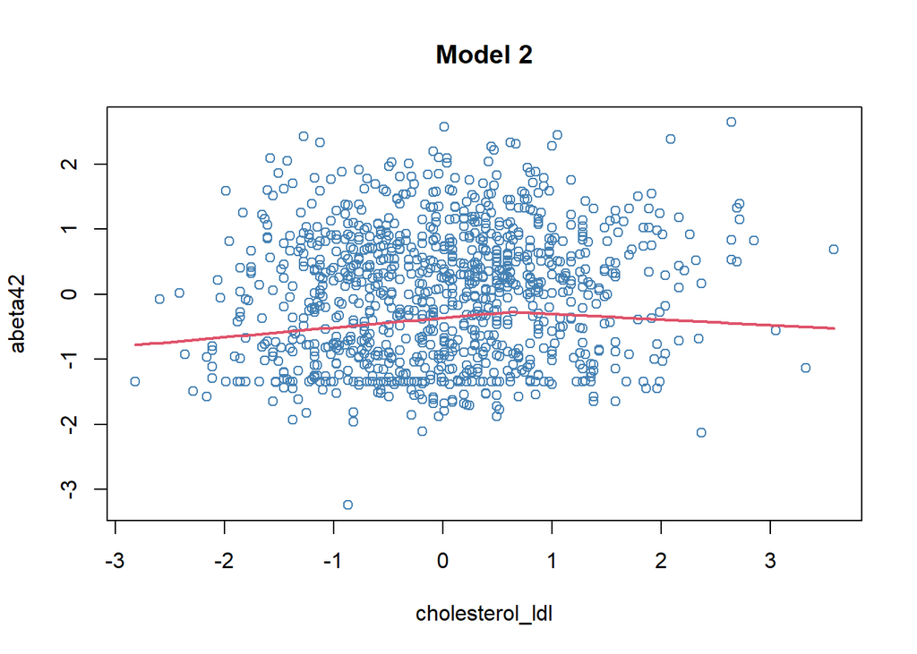

### Model 3 (modèle complet, MA = 0)

#### AIC

```
## [1] 1384.11
```

#### segment

```
##
##  ***Regression Model with Segmented Relationship(s)***
##
## Call:
## segmented.lm(obj = mod3, seg.Z = ~cholesterol_ldl, psi = 0)
##
## Estimated Break-Point(s):
##                        Est. St.Err
## psi1.cholesterol_ldl 0.746  0.691
##
## Meaningful coefficients of the linear terms:
##                                               Estimate Std. Error t value
## (Intercept)                                  -1.514707   0.365466  -4.145
## cholesterol_ldl                               0.106906   0.058887   1.815
## age                                           0.023640   0.004055   5.829
## sexeTRUE                                     -0.002157   0.073098  -0.030
## niveau_etude_regniveau études intermédiaires -0.194457   0.083229  -2.336
## niveau_etude_regniveau études mineurs         0.037945   0.099111   0.383
## mmse                                         -0.025399   0.008068  -3.148
## ch                                            0.088982   0.100291   0.887
## dia                                           0.026309   0.132023   0.199
## hta_med                                       0.037925   0.089178   0.425
## imc_regInsuffisance pondérale                -0.122493   0.188393  -0.650
## imc_regObésité                               -0.084708   0.110340  -0.768
## imc_regSurpoids                              -0.088478   0.078672  -1.125
## apoe.reg2                                     0.629939   0.061424  10.256
## U1.cholesterol_ldl                           -0.211483   0.172768  -1.224
##                                              Pr(>|t|)
## (Intercept)                                  3.95e-05 ***
## cholesterol_ldl                               0.07001 .
## age                                          9.55e-09 ***
## sexeTRUE                                      0.97647
## niveau_etude_regniveau études intermédiaires  0.01983 *
## niveau_etude_regniveau études mineurs         0.70198
## mmse                                          0.00173 **
## ch                                            0.37534
## dia                                           0.84212
## hta_med                                       0.67080
## imc_regInsuffisance pondérale                 0.51584
## imc_regObésité                                0.44300
## imc_regSurpoids                               0.26124
## apoe.reg2                                     < 2e-16 ***
## U1.cholesterol_ldl                                 NA
## ---
## Signif. codes:  0 '***' 0.001 '**' 0.01 '*' 0.05 '.' 0.1 ' ' 1
##
## Residual standard error: 0.821 on 544 degrees of freedom
## Multiple R-Squared: 0.2578,  Adjusted R-squared: 0.2373
##
## Boot restarting based on 9 samples. Last fit:
## Convergence attained in 2 iterations (rel. change 4.5658e-09)
```

#### AIC Segment

```
## [1] 1386.123
```

#### Plot

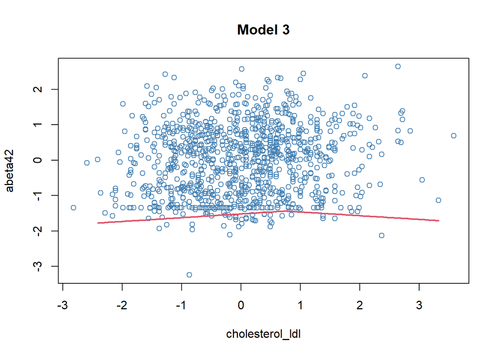

#### Calcul ldl1 et ldl2

```
##    Min. 1st Qu.  Median    Mean 3rd Qu.    Max.
## -2.4168 -0.7722 -0.1144 -0.1971  0.4992  0.7460
```

```
##    Min. 1st Qu.  Median    Mean 3rd Qu.    Max.
##  0.0000  0.0000  0.0000  0.1091  0.0000  2.5807
```

#### Modèle linéaire avec ldl 1 et ldl 2

```
##
## Call:
## lm(formula = abeta42 ~ ldl1 + ldl2 + age + sexe + niveau_etude_reg +
##     mmse + ch + dia + hta_med + imc_reg + apoe.reg2, data = data_ma_0)
##
## Residuals:
##      Min       1Q   Median       3Q      Max
## -2.83793 -0.57512 -0.07743  0.50399  2.75799
##
## Coefficients:
##                                               Estimate Std. Error t value
## (Intercept)                                  -1.514709   0.364680  -4.154
## ldl1                                          0.106902   0.053888   1.984
## ldl2                                         -0.104592   0.123191  -0.849
## age                                           0.023639   0.004052   5.835
## sexeTRUE                                     -0.002158   0.072777  -0.030
## niveau_etude_regniveau études intermédiaires -0.194456   0.083099  -2.340
## niveau_etude_regniveau études mineurs         0.037945   0.099019   0.383
## mmse                                         -0.025399   0.008060  -3.151
## ch                                            0.088983   0.100192   0.888
## dia                                           0.026309   0.131872   0.200
## hta_med                                       0.037925   0.089086   0.426
## imc_regInsuffisance pondérale                -0.122494   0.188220  -0.651
## imc_regObésité                               -0.084709   0.110225  -0.769
## imc_regSurpoids                              -0.088478   0.078600  -1.126
## apoe.reg2                                     0.629938   0.061154  10.301
##                                              Pr(>|t|)
## (Intercept)                                  3.80e-05 ***
## ldl1                                          0.04778 *
## ldl2                                          0.39624
## age                                          9.25e-09 ***
## sexeTRUE                                      0.97636
## niveau_etude_regniveau études intermédiaires  0.01964 *
## niveau_etude_regniveau études mineurs         0.70171
## mmse                                          0.00171 **
## ch                                            0.37487
## dia                                           0.84194
## hta_med                                       0.67048
## imc_regInsuffisance pondérale                 0.51545
## imc_regObésité                                0.44252
## imc_regSurpoids                               0.26080
## apoe.reg2                                     < 2e-16 ***
## ---
## Signif. codes:  0 '***' 0.001 '**' 0.01 '*' 0.05 '.' 0.1 ' ' 1
##
## Residual standard error: 0.8203 on 545 degrees of freedom
## Multiple R-squared:  0.2578, Adjusted R-squared:  0.2387
## F-statistic: 13.52 on 14 and 545 DF,  p-value: < 2.2e-16
```

#### Modèle avec les variables centrées

```
##
## Call:
## lm(formula = abeta42 ~ cholesterol_ldl + age_med + sexe + niveau_etude_reg +
##     mmse_med + ch + dia + hta_med + imc_reg + apoe.reg2, data = data_ma_0)
##
## Residuals:
##      Min       1Q   Median       3Q      Max
## -2.86225 -0.61483 -0.07065  0.50652  2.73287
##
## Coefficients:
##                                        Estimate Std. Error t value Pr(>|t|)
## (Intercept)                           -0.728018   0.092317  -7.886 1.71e-14 ***
## cholesterol_ldl                        0.057372   0.040505   1.416  0.15722
## age_med                                0.023413   0.004052   5.778 1.27e-08 ***
## sexeTRUE                              -0.008048   0.072716  -0.111  0.91192
## niveau_etude_regétudes supérieurs      0.188208   0.083049   2.266  0.02383 *
## niveau_etude_regniveau études mineurs  0.226747   0.096510   2.349  0.01916 *
## mmse_med                              -0.024987   0.008061  -3.100  0.00204 **
## ch                                     0.075126   0.099782   0.753  0.45183
## dia                                    0.016641   0.131802   0.126  0.89958
## hta_med                                0.036151   0.089153   0.405  0.68528
## imc_regInsuffisance pondérale         -0.124821   0.188374  -0.663  0.50785
## imc_regObésité                        -0.087542   0.110301  -0.794  0.42774
## imc_regSurpoids                       -0.095442   0.078508  -1.216  0.22462
## apoe.reg2                              0.632757   0.061173  10.344  < 2e-16 ***
## ---
## Signif. codes:  0 '***' 0.001 '**' 0.01 '*' 0.05 '.' 0.1 ' ' 1
##
## Residual standard error: 0.821 on 546 degrees of freedom
## Multiple R-squared:  0.2551, Adjusted R-squared:  0.2374
## F-statistic: 14.39 on 13 and 546 DF,  p-value: < 2.2e-16
```

#### Plot avec les variables centrées

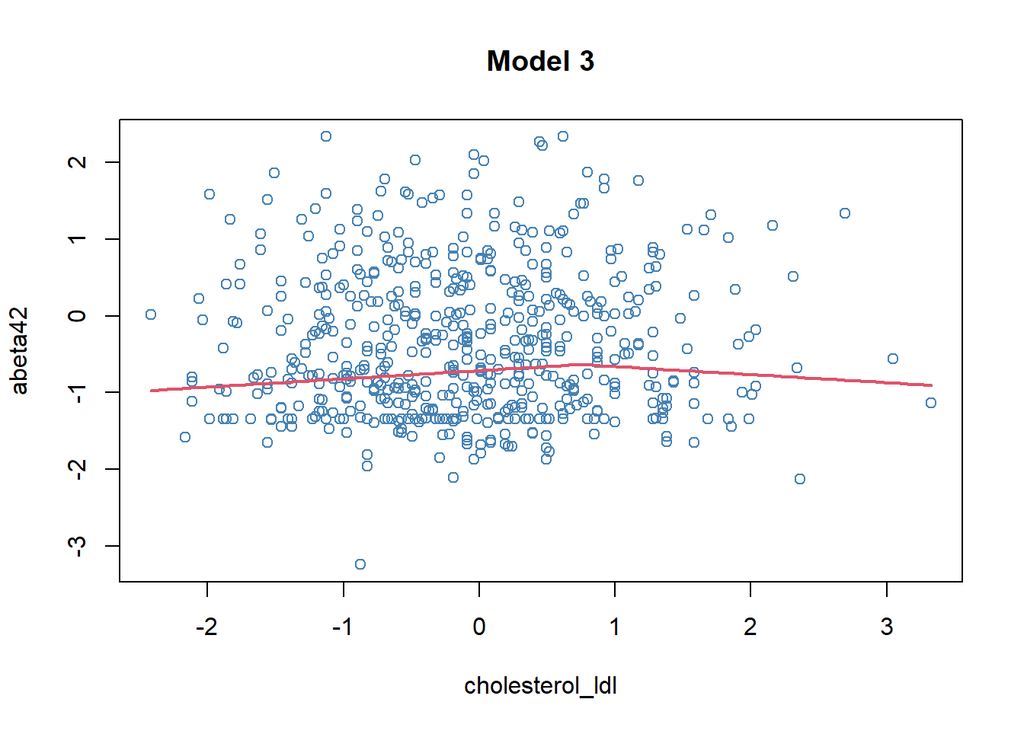

### Model 4 (modèle complet, MA = 1)

#### AIC

```
## [1] 1051.607
```

#### segment

```
##
##  ***Regression Model with Segmented Relationship(s)***
##
## Call:
## segmented.lm(obj = mod4, seg.Z = ~cholesterol_ldl, psi = 0)
##
## Estimated Break-Point(s):
##                         Est. St.Err
## psi1.cholesterol_ldl -0.393  0.353
##
## Meaningful coefficients of the linear terms:
##                                               Estimate Std. Error t value
## (Intercept)                                   1.328769   0.408900   3.250
## cholesterol_ldl                               0.364897   0.138345   2.638
## age                                           0.003425   0.004546   0.753
## sexeTRUE                                     -0.170877   0.080315  -2.128
## niveau_etude_regniveau études intermédiaires -0.041436   0.090802  -0.456
## niveau_etude_regniveau études mineurs        -0.377795   0.101844  -3.710
## mmse                                         -0.040502   0.007613  -5.320
## ch                                            0.012583   0.110405   0.114
## dia                                           0.052177   0.152751   0.342
## hta_med                                      -0.122059   0.086353  -1.413
## imc_regInsuffisance pondérale                -0.304032   0.180441  -1.685
## imc_regObésité                               -0.317081   0.134833  -2.352
## imc_regSurpoids                              -0.073743   0.083461  -0.884
## apoe.reg2                                     0.390108   0.053911   7.236
## U1.cholesterol_ldl                           -0.392399   0.150516  -2.607
##                                              Pr(>|t|)
## (Intercept)                                  0.001247 **
## cholesterol_ldl                              0.008654 **
## age                                          0.451582
## sexeTRUE                                     0.033943 *
## niveau_etude_regniveau études intermédiaires 0.648380
## niveau_etude_regniveau études mineurs        0.000235 ***
## mmse                                         1.68e-07 ***
## ch                                           0.909312
## dia                                          0.732832
## hta_med                                      0.158239
## imc_regInsuffisance pondérale                0.092729 .
## imc_regObésité                               0.019142 *
## imc_regSurpoids                              0.377423
## apoe.reg2                                    2.15e-12 ***
## U1.cholesterol_ldl                                 NA
## ---
## Signif. codes:  0 '***' 0.001 '**' 0.01 '*' 0.05 '.' 0.1 ' ' 1
##
## Residual standard error: 0.7715 on 428 degrees of freedom
## Multiple R-Squared: 0.2423,  Adjusted R-squared: 0.2157
##
## Boot restarting based on 6 samples. Last fit:
## Convergence attained in 2 iterations (rel. change 1.9491e-10)
```

#### AIC Segment

```
## [1] 1047.382
```

#### Plot

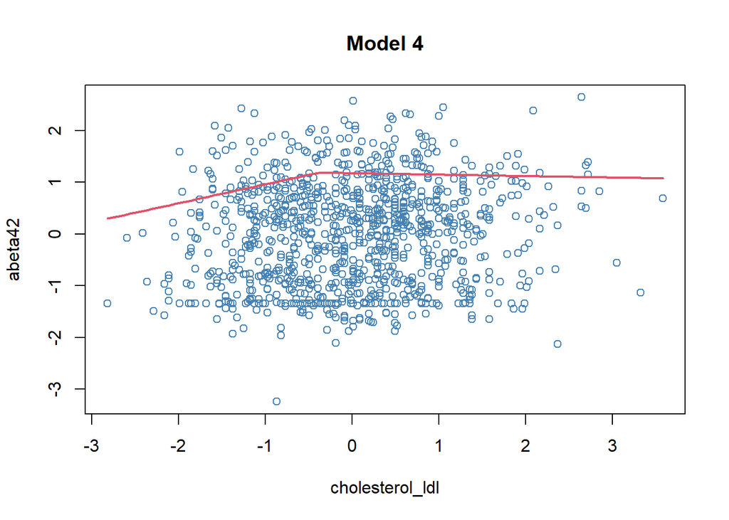

#### Calcul ldl1 et ldl2

```
##    Min. 1st Qu.  Median    Mean 3rd Qu.    Max.
## -2.8217 -0.6710 -0.3930 -0.6127 -0.3930 -0.3930
```

```
##    Min. 1st Qu.  Median    Mean 3rd Qu.    Max.
##  0.0000  0.0000  0.5823  0.7237  1.1895  3.9727
```

#### Modèle linéaire avec ldl 1 et ldl 2

```
##
## Call:
## lm(formula = abeta42 ~ ldl1 + ldl2 + age + sexe + niveau_etude_reg +
##     mmse + ch + dia + hta_med + imc_reg + apoe.reg2, data = data_ma_1)
##
## Residuals:
##      Min       1Q   Median       3Q      Max
## -1.89277 -0.49361  0.05681  0.46560  2.29997
##
## Coefficients:
##                                               Estimate Std. Error t value
## (Intercept)                                   1.328901   0.381389   3.484
## ldl1                                          0.364977   0.105314   3.466
## ldl2                                         -0.027473   0.056242  -0.488
## age                                           0.003425   0.004536   0.755
## sexeTRUE                                     -0.170878   0.080212  -2.130
## niveau_etude_regniveau études intermédiaires -0.041437   0.090696  -0.457
## niveau_etude_regniveau études mineurs        -0.377795   0.101725  -3.714
## mmse                                         -0.040502   0.007604  -5.326
## ch                                            0.012581   0.110244   0.114
## dia                                           0.052175   0.152545   0.342
## hta_med                                      -0.122059   0.086252  -1.415
## imc_regInsuffisance pondérale                -0.304042   0.179896  -1.690
## imc_regObésité                               -0.317093   0.134010  -2.366
## imc_regSurpoids                              -0.073744   0.083362  -0.885
## apoe.reg2                                     0.390103   0.053657   7.270
##                                              Pr(>|t|)
## (Intercept)                                  0.000544 ***
## ldl1                                         0.000582 ***
## ldl2                                         0.625456
## age                                          0.450597
## sexeTRUE                                     0.033711 *
## niveau_etude_regniveau études intermédiaires 0.647994
## niveau_etude_regniveau études mineurs        0.000231 ***
## mmse                                         1.62e-07 ***
## ch                                           0.909197
## dia                                          0.732498
## hta_med                                      0.157751
## imc_regInsuffisance pondérale                0.091736 .
## imc_regObésité                               0.018416 *
## imc_regSurpoids                              0.376857
## apoe.reg2                                    1.71e-12 ***
## ---
## Signif. codes:  0 '***' 0.001 '**' 0.01 '*' 0.05 '.' 0.1 ' ' 1
##
## Residual standard error: 0.7706 on 429 degrees of freedom
## Multiple R-squared:  0.2423, Adjusted R-squared:  0.2176
## F-statistic: 9.798 on 14 and 429 DF,  p-value: < 2.2e-16
```

#### Modèle avec les variables centrées

```
##
## Call:
## lm(formula = abeta42 ~ cholesterol_ldl + age_med + sexe + niveau_etude_reg +
##     mmse_med + ch + dia + hta_med + imc_reg + apoe.reg2, data = data_ma_1)
##
## Residuals:
##     Min      1Q  Median      3Q     Max
## -1.8858 -0.4786  0.0344  0.4821  2.2652
##
## Coefficients:
##                                        Estimate Std. Error t value Pr(>|t|)
## (Intercept)                            0.432520   0.095492   4.529 7.67e-06 ***
## cholesterol_ldl                        0.087738   0.039152   2.241 0.025538 *
## age_med                                0.003625   0.004572   0.793 0.428238
## sexeTRUE                              -0.156527   0.080702  -1.940 0.053087 .
## niveau_etude_regétudes supérieurs      0.035829   0.091412   0.392 0.695284
## niveau_etude_regniveau études mineurs -0.329706   0.098694  -3.341 0.000909 ***
## mmse_med                              -0.041721   0.007654  -5.451 8.45e-08 ***
## ch                                    -0.004798   0.110968  -0.043 0.965530
## dia                                    0.014859   0.153211   0.097 0.922783
## hta_med                               -0.131058   0.086894  -1.508 0.132224
## imc_regInsuffisance pondérale         -0.307927   0.181354  -1.698 0.090243 .
## imc_regObésité                        -0.301809   0.134990  -2.236 0.025879 *
## imc_regSurpoids                       -0.073831   0.084040  -0.879 0.380150
## apoe.reg2                              0.383848   0.054048   7.102 5.13e-12 ***
## ---
## Signif. codes:  0 '***' 0.001 '**' 0.01 '*' 0.05 '.' 0.1 ' ' 1
##
## Residual standard error: 0.7769 on 430 degrees of freedom
## Multiple R-squared:  0.2281, Adjusted R-squared:  0.2048
## F-statistic: 9.775 on 13 and 430 DF,  p-value: < 2.2e-16
```

#### Plot avec les variables centrées

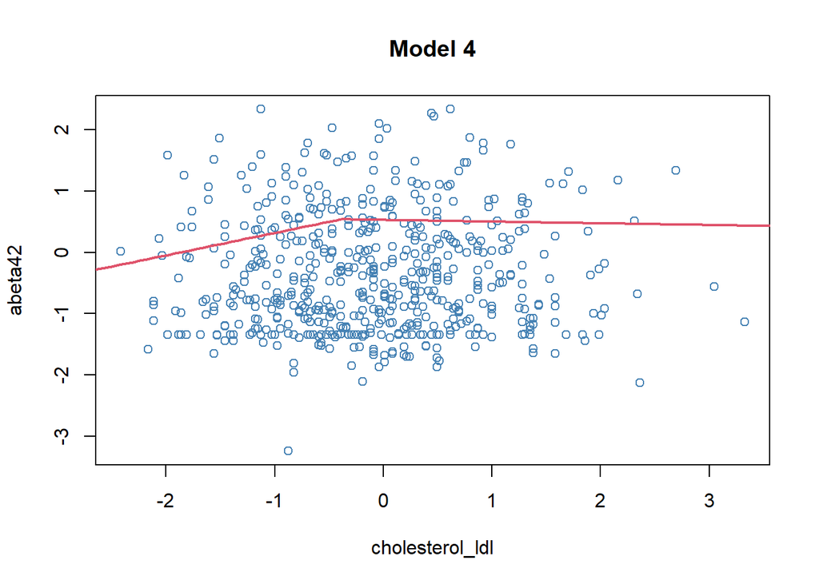